# Practical Machine Learning final course project

## Executive Summary

The goal of this study is to predict the manner in which participants did the exercise. The outcome variable for the model is classe, which is a factor variable with 5 levels. Classe is determined based on the way the study, participants performed one set of 10 repetitions of the Unilateral Dumbbell Biceps Curl. Here are desciptions of the 5 levels of Classe

- exactly according to the specification (Class A)
- throwing the elbows to the front (Class B)
- lifting the dumbbell only halfway (Class C)
- lowering the dumbbell only halfway (Class D)
- throwing the hips to the front (Class E)

Class A corresponds to the specified execution of the exercise, while the other 4 classes correspond to common mistakes."

Models will be evaluated based on the accuracy of prediction, and the predictors are selected by eliminating all variables near zero variance, those with missing predictors, and eliminating other variables like names, id’s, timestamps etc.,

```r
knitr::opts_chunk$set(echo = TRUE)
library(caret)
library(randomForest)
```

```r
library(rpart)
library(rpart.plot)
library(RColorBrewer)
library(rattle)
```

## Getting and cleaning Data

```r
    URL_training <- "https://d396qusza40orc.cloudfront.net/predmachlearn/pml-training.csv"
    URL_test <- "https://d396qusza40orc.cloudfront.net/predmachlearn/pml-testing.csv"
    masterTrainingSet <- read.csv(url(URL_training), na.strings = c("NA", "#DIV/0!",""))
    finalTestingSet  <- read.csv(url(URL_test), na.strings = c("NA", "#DIV/0!",""))
```

## Partioning the training set into two

```r
    set.seed(12334)
    inTrain <- createDataPartition(y=masterTrainingSet$classe,p=0.75, list = FALSE)
    trainingSet <- masterTrainingSet[inTrain,]
    testingSet <- masterTrainingSet[-inTrain,]
```

## Data Cleanup

First, I remove the variables like ID, name, timestamps, window etc., from the dataset to avoid any potential interference with the prediction algorithms

```r
notVar1 <- grep("name|timestamp|window|X", colnames(trainingSet), value=F)
trainingSet <- trainingSet[-notVar1]
dim(trainingSet)
```

```
## [1] 14718   153
```

Given the large number of predicotr at this stage, I will remove any columns that have atleast one NA value in them i.e., only keep columns where there are no missing values (NA’s)

```r
trainingSet<-trainingSet[,colSums(is.na(trainingSet)) == 0]
dim(trainingSet)
```

```
## [1] 14718    53
```

Now, we will look for and eliminate any predictors that have a near zero variance

```r
#remove any Variables with NearZeroVariance where freqCut >19, and uniqueCut < 10 (default values)
myDataNZV <- nearZeroVar(trainingSet, freqCut = 95/5, uniqueCut= 10, saveMetrics=TRUE)
nonNZVvars <- subset(myDataNZV, nzv == FALSE)
trainingSet <- trainingSet[rownames(nonNZVvars)]
dim(trainingSet)
```

```
## [1] 14718    53
```

Given that the data is down to a more manageable no. of predictors (53), let’s look at the frequency of our output variable ‘classe’

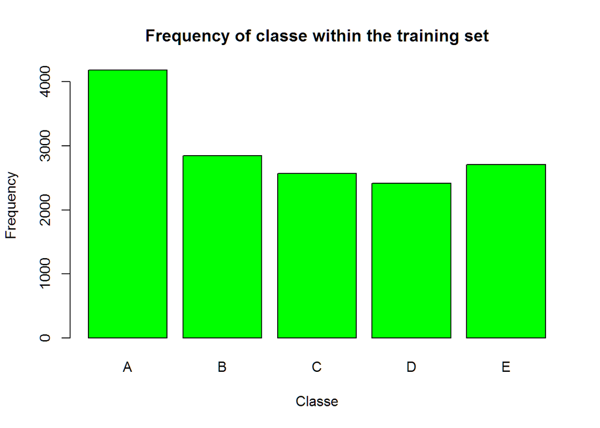

```r
plot(trainingSet$classe, col="green", main="Frequency of classe within the training set", xlab="Classe", ylab="Frequency")
```

From the graph above, we can see that each level frequency is within the same order of magnitude of each other. Level A is the most frequent with more than 4000 occurrences while level D is the least frequent with about 2500 occurrences

Next, I filter by cross-validation testing set, and the master testing set to the set of shortlisted predictors used for the training data

```r
#Transformation 4
#Transform the testing data sets the same way
cleanColNames <- names(trainingSet)
testingSet <- testingSet[cleanColNames]
dim(testingSet)
```

```
## [1] 4904   53
```

```r
finalTestingSet <- finalTestingSet[cleanColNames[1:52]] #testing does not the classe variable
```

Finally, in order to elimate any interference from non-coherent data types in the training and prediction set, I coerce the data into the same type.

```r
for (i in 1:length(finalTestingSet) ) {
    for(j in 1:length(trainingSet)) {
        if( length( grep(names(trainingSet[i]), names(finalTestingSet)[j]) ) ==1)  {
            class(finalTestingSet[j]) <- class(trainingSet[i])
        }
    }
}
```

## Decision Tree Model

I use the subsetted training data to fit an rpart decision-tree model

```r
modFitDT <- train(classe ~ ., data=trainingSet, method="rpart") #try with method = "class"
```

let’s view the decision tree with fancy

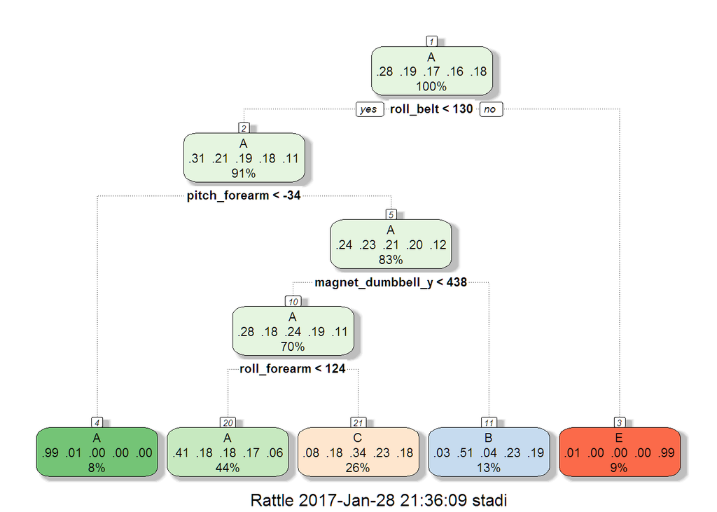

```r
fancyRpartPlot(modFitDT$finalModel)
```

lets use the subset of the test data to predict classe, and see model fit

```r
predictDT <- predict(modFitDT, newdata = testingSet)
confusionMatrix(predictDT, testingSet$classe)
```

```
## Confusion Matrix and Statistics
##
##           Reference
## Prediction    A    B    C    D    E
##          A 1258  389  410  346  131
##          B   29  323   25  147  128
##          C  105  237  420  311  255
##          D    0    0    0    0    0
##          E    3    0    0    0  387
##
## Overall Statistics
##
##                Accuracy : 0.4869
##                  95% CI : (0.4729, 0.501)
##     No Information Rate : 0.2845
##     P-Value [Acc > NIR] : < 2.2e-16
##
##                   Kappa : 0.3297
##  Mcnemar's Test P-Value : NA
##
## Statistics by Class:
##
##                      Class: A Class: B Class: C Class: D Class: E
## Sensitivity            0.9018  0.34036  0.49123   0.0000  0.42952
## Specificity            0.6364  0.91681  0.77575   1.0000  0.99925
## Pos Pred Value         0.4964  0.49540  0.31627      NaN  0.99231
## Neg Pred Value         0.9422  0.85278  0.87836   0.8361  0.88613
## Prevalence             0.2845  0.19352  0.17435   0.1639  0.18373
## Detection Rate         0.2565  0.06586  0.08564   0.0000  0.07892
## Detection Prevalence   0.5167  0.13295  0.27080   0.0000  0.07953
## Balanced Accuracy      0.7691  0.62859  0.63349   0.5000  0.71439
```

We get an accuracy rate of ~48.7 % which is not that great.

## Random Forests Model

```r
#Second prediction model: Using Random Forests
modFitRF <- train(classe ~ ., data=trainingSet, method="rf")
predictRF <- predict(modFitRF, newdata = testingSet)
confusionMatrix(predictRF, testingSet$classe)
```

```
## Confusion Matrix and Statistics
##
##           Reference
## Prediction    A    B    C    D    E
##          A 1393    9    0    0    0
##          B    0  934    4    0    0
##          C    0    6  850   10    2
##          D    0    0    1  794    4
##          E    2    0    0    0  895
##
## Overall Statistics
##
##                Accuracy : 0.9923
##                  95% CI : (0.9894, 0.9945)
##     No Information Rate : 0.2845
##     P-Value [Acc > NIR] : < 2.2e-16
##
##                   Kappa : 0.9902
##  Mcnemar's Test P-Value : NA
##
## Statistics by Class:
##
##                      Class: A Class: B Class: C Class: D Class: E
## Sensitivity            0.9986   0.9842   0.9942   0.9876   0.9933
## Specificity            0.9974   0.9990   0.9956   0.9988   0.9995
## Pos Pred Value         0.9936   0.9957   0.9793   0.9937   0.9978
## Neg Pred Value         0.9994   0.9962   0.9988   0.9976   0.9985
## Prevalence             0.2845   0.1935   0.1743   0.1639   0.1837
## Detection Rate         0.2841   0.1905   0.1733   0.1619   0.1825
## Detection Prevalence   0.2859   0.1913   0.1770   0.1629   0.1829
## Balanced Accuracy      0.9980   0.9916   0.9949   0.9932   0.9964
```

## Predicting the Classe for real test data

```r
finalPrediction <- predict(modFitRF, finalTestingSet)
finalPrediction
```

```
##  [1] B A B A A E D B A A B C B A E E A B B B
## Levels: A B C D E
```